# Mendota_timeseries

Lauren A. Knose, ORISE-EPA

2023-05-02

The purpose of this program is to analyze the Mendota nutrient and water quality data using time series analysis.

# Step 1. Load dependent packages and data needed:

1. Loading dependent packages…

```r
library(ggplot2) #needed for plots
library(ggbreak) #needed for plot scale breaks
library(dplyr) #needed for reshaping/reformaing data
library(lubridate) #needed for date functions
library(zoo) #needed to interpolate data
library(xts) #needed to convert data frame to time series
```

2. Loading data… Note, ensure date data is formatted in R as Date.

```r
Me_P_water<- read.csv(file="Cleaned_data/Mendota_P_water.csv")
Me_P_water<- Me_P_water %>%
  mutate(sampledate=as.Date(sampledate, origin="1899-12-30"), #format as date
         X=NULL) #remove extra column
Me_Chla<- read.csv(file="Cleaned_data/Mendota_Chl.csv")
Me_Chla<- Me_Chla %>%
  mutate(sampledate=as.Date(sampledate, origin="1899-12-30"), #format as date
         X=NULL) #remove extra column
Me_Cyano<- read.csv(file="Cleaned_data/Mendota_Cyano.csv")
Me_Cyano<- Me_Cyano %>%
  mutate(sampledate=as.Date(sampledate, origin="1899-12-30"), #format as date
         X=NULL) #remove extra column
Me_P_extinfl<- read.csv(file="Cleaned_data/Mendota_inflows.csv")
Me_P_extinfl<- Me_P_extinfl %>%
  mutate(sampledate=as.Date(sampledate, origin="1899-12-30"), #format as date
         X=NULL) #remove extra column=as.Date(sampledate, orig))
```

# Step 2. Combine data into one data file:

1. Merging nutrient data with Chl-a data by sample date…

```r
Me_Chla <- Me_Chla %>%
  mutate(Yr=NULL, Mo=NULL, MoYr=NULL, daynum=NULL) #remove excess columns
water<- merge(Me_P_water, Me_Chla, by="sampledate")
```

Nutrient and Chl-a data merged.

2. Merging nutrient data with Cyano data by sample date…

```r
Me_Cyano<- Me_Cyano %>%
  mutate(Yr=NULL, Mo=NULL, MoYr=NULL, daynum=NULL) #remove excess columns
water<- merge(water, Me_Cyano, by="sampledate")
```

Nutrient and cyano data merged.

3. Merging external loading with other data by sample date…

```r
water<- merge(water, Me_P_extinfl, by="sampledate")
```

# Step 3. View data:

1. plotting Hypo: Epi total P…

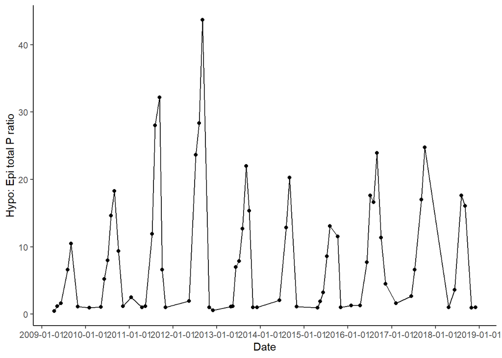

```r
ggplot(data=subset(water, year(sampledate)> 2008), #need to subset data because of big gap between 2000 and 2008
       aes(x=sampledate, y=HE_ratio_TotP_mgL)) +
  geom_point() +
  geom_line() +
  theme_classic() +
  labs(x="Date", y="Hypo: Epi total P ratio") +
  scale_x_date(date_breaks="1 year")
```

Hypo: Epi total P ratio plotted.

2. plotting chl-a…

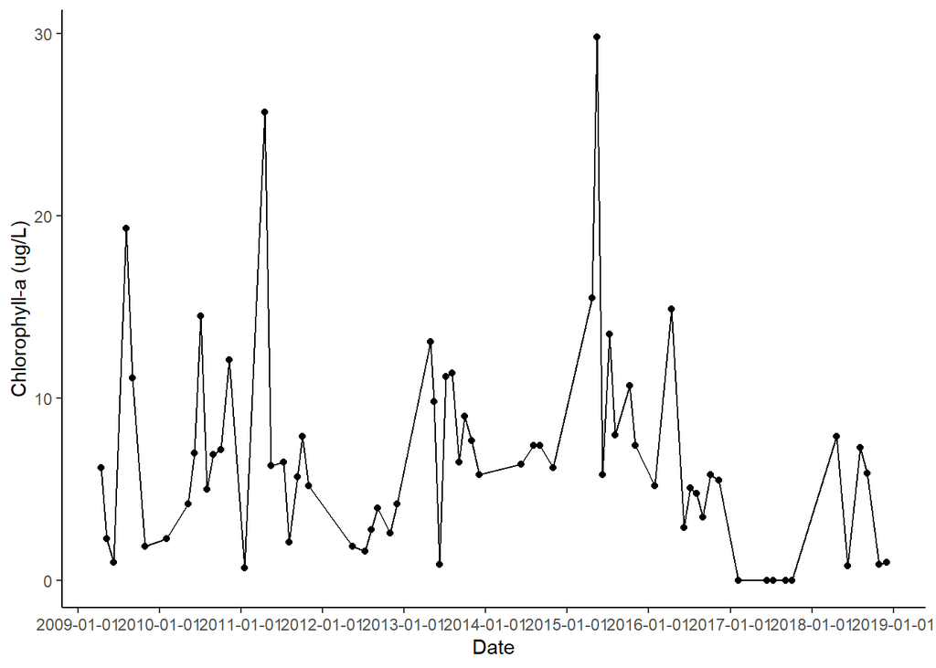

```r
ggplot(data=subset(water, year(sampledate)> 2008), #need to subset data because of big gap between 2000 and 2008
       aes(x=sampledate,  y=Chla_ugL)) +
  geom_point() +
  geom_line() +
  theme_classic() +
  labs(x="Date", y="Chlorophyll-a (ug/L)") +
  scale_x_date(date_breaks="1 year")
```

Chl-a plotted.

3. plotting Cyano relative biovolume…

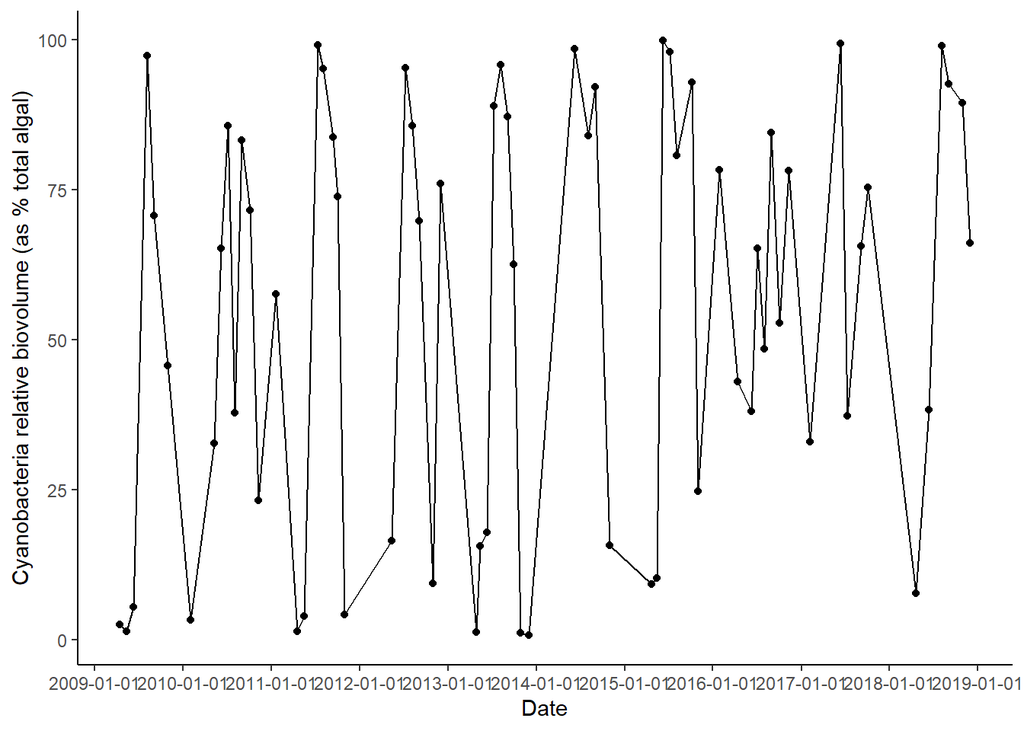

```r
ggplot(data=subset(water, year(sampledate)> 2008), #need to subset data because of big gap between 2000 and 2008
       aes(x=sampledate,  y=relbiovol)) +
  geom_point() +
  geom_line() +
  theme_classic() +
  labs(x="Date", y="Cyanobacteria relative biovolume (as % total algal)") +
  scale_x_date(date_breaks="1 year")
```

Cyanobacteria relative biovolume plotted.

4. plotting P external loading…

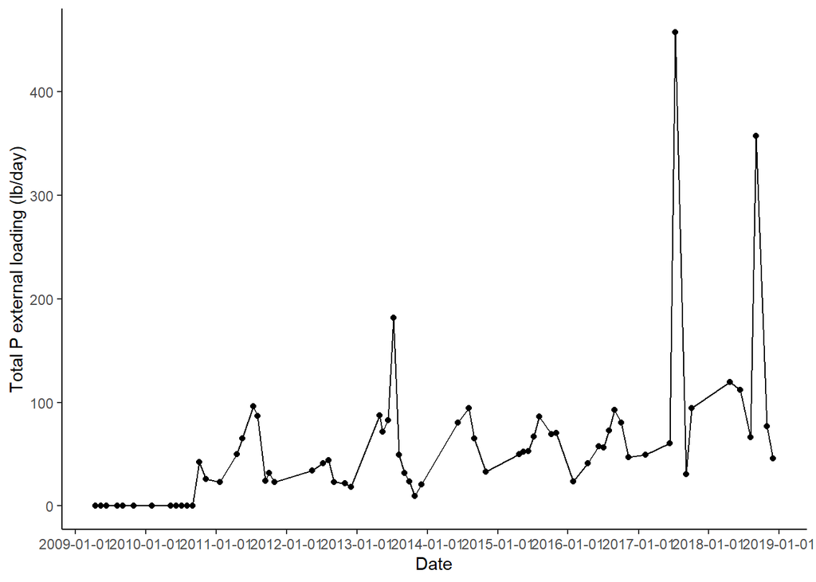

```r
ggplot(data=subset(water, year(sampledate)> 2008), #need to subset data because of big gap between 2000 and 2008
       aes(x=sampledate,  y=TotP_lbday_sum)) +
  geom_point() +
  geom_line() +
  theme_classic() +
  labs(x="Date", y="Total P external loading (lb/day)") +
  scale_x_date(date_breaks="1 year")
```